# 1 The Yaounde COVID-19 dataset

In this lesson, we will again use the data from the COVID-19 serological survey conducted in Yaounde, Cameroon.

```r
yaounde <- read_csv(here::here('ch04_data_wrangling/data/yaounde_data.csv'))
## a smaller subset of variables
yao <- yaounde %>%
  select(age, sex, weight_kg, highest_education, neighborhood,
         occupation, is_smoker, is_pregnant,
         igg_result, igm_result)
yao
```

| age | sex | weight_kg | highest_education | neighborhood | occupation | is_smoker | is_pregnant | igg_result | igm_result |
| --- | --- | --- | --- | --- | --- | --- | --- | --- | --- |
| 45 | Female | 95 | Secondary | Briqueterie | Informal worker | Non-smoker | No | Negative | Negative |
| 55 | Male | 96 | University | Briqueterie | Salaried worker | Ex-smoker | NA | Positive | Negative |
| 23 | Male | 74 | University | Briqueterie | Student | Smoker | NA | Negative | Negative |
| 20 | Female | 70 | Secondary | Briqueterie | Student | Non-smoker | No | Positive | Negative |
| 55 | Female | 67 | Primary | Briqueterie | Trader--Farmer | Non-smoker | No | Positive | Negative |
| 17 | Female | 65 | Secondary | Briqueterie | Student | Non-smoker | No | Negative | Negative |
| 13 | Female | 65 | Secondary | Briqueterie | Student | Non-smoker | No | Positive | Negative |
| 28 | Male | 62 | Doctorate | Briqueterie | Student | Non-smoker | NA | Negative | Negative |
| 30 | Male | 73 | Secondary | Briqueterie | Trader | Non-smoker | NA | Negative | Negative |
| 13 | Female | 56 | Secondary | Briqueterie | Other | Non-smoker | No | Positive | Negative |

[output cut: 961 more lines]

Let’s make a data subset to illustrate this.

```r
yao_mini <- yao %>%
  select(sex, is_pregnant) %>%
  slice(1,11,50,2) ## custom row order

yao_mini
```

| sex | is_pregnant |
| --- | --- |
| Female | No |
| Female | No response |
| Female | Yes |
| Male | NA |

## 1.1 A common error with `NA`

Handling `NA`s improperly is often a source of error. Imagine, for example, that we we wanted to drop pregnant women from the dataset.

We might write `filter(is_pregnant != "Yes")` (to be read as “keep respondents who are not pregnant”), but this would be wrong!

```r
## keep rows where `is_pregnant` is not "Yes"
yao_mini %>% filter(is_pregnant != "Yes") ## bad
```

| sex | is_pregnant |
| --- | --- |
| Female | No |
| Female | No response |

Do you see what went wrong? We wanted to drop the pregnant woman, but we dropped the man too!

This is because `filter()` drops all rows where the test evaluates to `NA`. And the test `NA != "Yes"` evaluates to `NA`, because R does not not whether `NA` is equal to or not equal to “Yes”.

```r
NA != "Yes" ## R does not know whether `NA` is equal to or not equal to "Yes"
```

```
## [1] NA
```

In order to correctly filter on a column that contains `NA`s, we often need to include an `is.na()` condition. So to drop pregnant women without accidentally dropping the man, we could write:

```r
## keep rows where `is_pregnant` is not "Yes"
yao_mini %>% filter(is_pregnant != "Yes" |
                    is.na(is_pregnant)) ## OR `is_pregnant` is NA
```

| sex | is_pregnant |
| --- | --- |
| Female | No |
| Female | No response |
| Male | NA |

Alternatively, we could write:

```r
## keep rows where `is_pregnant` is `NA`, "No" or "No response"
yao_mini %>%
  filter(is.na(is_pregnant) | is_pregnant == "No" | is_pregnant == "No response")
```

| sex | is_pregnant |
| --- | --- |
| Female | No |
| Female | No response |
| Male | NA |

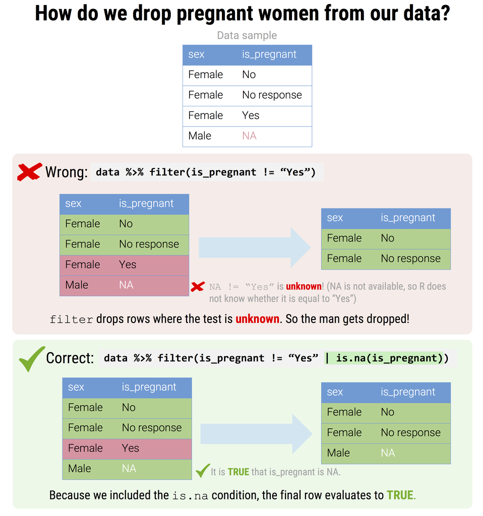

Remember that dropping some rows is like keeping their opposite.

An example:

- dropping anyone younger than 45 (in code: `filter(!(age < 45))`)

**is THE SAME as**

**Advantage**: less parenthesis and clearer to reread ! You should always go for the simplest code.